# Programación agéntica con Claude Code

Automatizando el análisis del modelo AVM

José Luis Canadas

PyData Granada 2026

2026-05-14

## Sobre mí

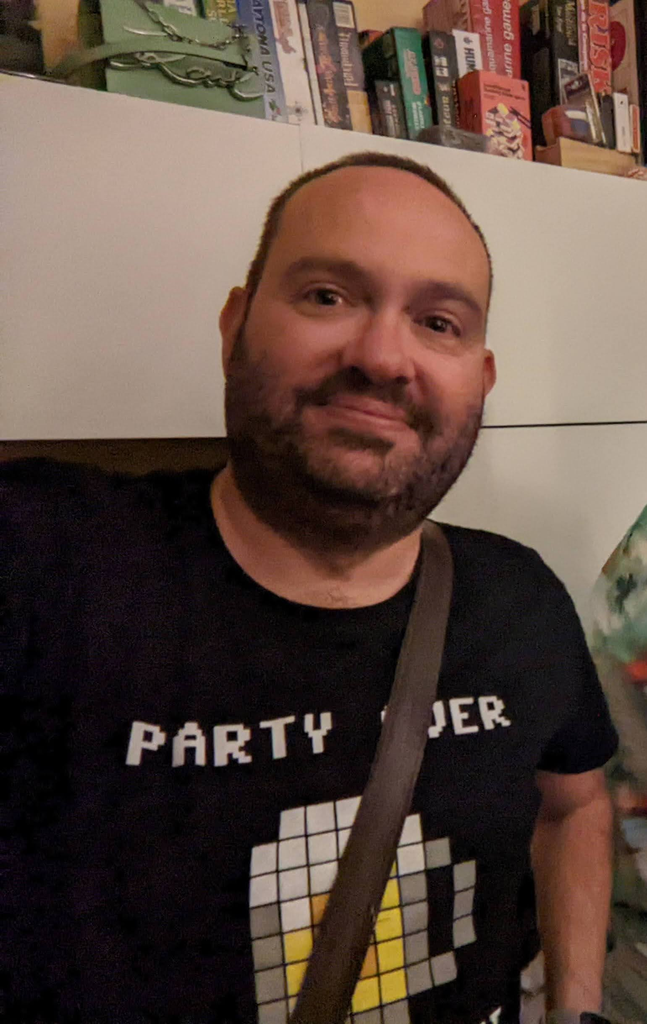

- Soy José Luis Cañadas Reche 👋
- Data Scientist @ idealista 🏠
- Muchos años en R, algo de Python, sql, spark, julia

## El temido jira

[figure not shown]

## El problema de siempre

La queja del usuario:

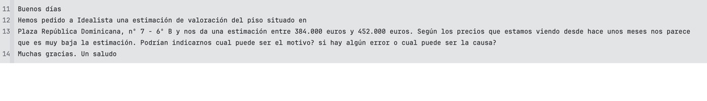

## A ver qué pone en la BD !

La respuesta requiere consultar ClickHouse manualmente:

[figure not shown]

**Mismas queries, mismo análisis, mismo informe — una y otra vez.**

# La solución: una *skill*

## La solución: una *skill* de Claude Code

Una herramienta que el agente invoca de forma autónoma:

1. Consulta los datos en ClickHouse
2. Genera visualizaciones de evolución de precios
3. Produce un informe HTML reproducible con Quarto

```
/clickhouse-avm-queries ref=<referencia_catastral>
/clickhouse-avm-queries-python ref=<referencia_catastral>
```

## ¿Qué es una skill de Claude Code?

```markdown
<!-- ~/.claude/skills/clickhouse-avm-queries.md -->
# Skill: ClickHouse AVM Queries

Use when querying ClickHouse AVM data by cadastral reference...

## When to use
...

## Steps
1. Connect to ClickHouse
2. Run parametrized queries
3. Render Quarto report
```

Un fichero Markdown que el agente lee como instrucciones de contexto.

# El proceso:

## El proceso: primero R

- Lenguaje de confort para prototipar para mi.
- Iteración rápida con `{tidyverse}` y `{ggplot2}`
- Validar la lógica de negocio antes de invertir tiempo

```r
con <- dbConnect(clickhouse(), ...)
precio_evolucion <- tbl(con, "avm_predictions") |>
  filter(ref_catastral == ref) |>
  collect()
```

> El objetivo: entender el dominio del problema, no el lenguaje.

## Luego Python, sin esfuerzo ninguno

Con la lógica validada en R, el agente portó el código a Python:

| Concepto | R | Python |
| --- | --- | --- |
| Driver | `RClickhouse` (puerto 9000) | `clickhouse-connect` (puerto 8123) |
| Resultado query | `data.frame` | `pandas.DataFrame` |
| Visualización | `ggplot2` | `seaborn` + `matplotlib` |
| Dependencias | `renv` + `renv.lock` | `uv` + `uv.lock` |
| Informe | Quarto `.qmd` (knitr) | Quarto `.qmd` (jupyter) |

El diff conceptual entre versiones: **prácticamente cero**.

# Más allá de la automatización

## Más allá de la automatización

El flujo completo con la skill Python:

```bash
# Paso 1 — análisis e interpretación (salida en terminal)
uv run python generar_informe_inteligente.py 6929001VG4162H0044QZ

# Paso 2 — informe HTML adaptado
uv run quarto render informe_catastral.qmd \
  -P cadastral_ref:6929001VG4162H0044QZ
```

El agente no solo ejecuta la query.

Lee el resultado, **interpreta** los datos y **modifica el informe** antes de renderizarlo.

Esto ya no es automatización — es **análisis asistido por IA**.

## El aprendizaje real

> Con un agente como colaborador, el lenguaje de programación deja de ser el cuello de botella.

El foco vuelve donde debe estar: **el conocimiento del dominio**.

Y el agente ya no solo ejecuta — también **interpreta**.

## Qué hace posible esto

| Antes | Con agente |
| --- | --- |
| Necesitas saber el lenguaje | Necesitas saber el dominio |
| La herramienta condiciona el diseño | El diseño condiciona la herramienta |
| Prototipo = MVP definitivo | Prototipo → portamos en minutos |

# Demo en vivo

## Demo en vivo

*(consulta real sobre una referencia catastral)*

```
/clickhouse-avm-queries ref=6929001VG4162H0044QZ
```

## ¿Y si la skill no sabe responder?

```
/clickhouse-avm-queries ref=0474609WG2607C0001JB
```

> Error: no se encontraron datos para esta referencia catastral.

La ref `0474609WG2607C0001JB` es un **chalet** — tipología que no está en las tablas actuales de la skill.

El agente no falla de forma silenciosa: **te dice exactamente qué falta**.

# Para llevarse a casa

## Para llevarse a casa

- Las skills son **documentación ejecutable**: el agente las lee como tú leerías una guía interna
- Prototipar en tu lenguaje de confort sigue siendo válido; **portar ya no es caro**
- El cuello de botella hoy es el **conocimiento del dominio**, no el lenguaje

## Gracias

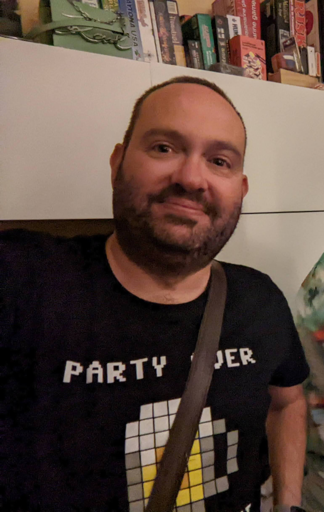

**José Luis Canadas**

Data Scientist @ idealista

`jlcanadas@idealista.com`